# Instructions: Using Spark with Databricks

Dr Paraskevi Pericleous and Michael Hoskin

19/02/2019

[figure not shown]

# How to Register

Go to https://databricks.com/ and click on `Try Databricks Free`.

[figure not shown]

Click on `Get Started` with the Community Edition which takes you to https://databricks.com/signup#signup/community

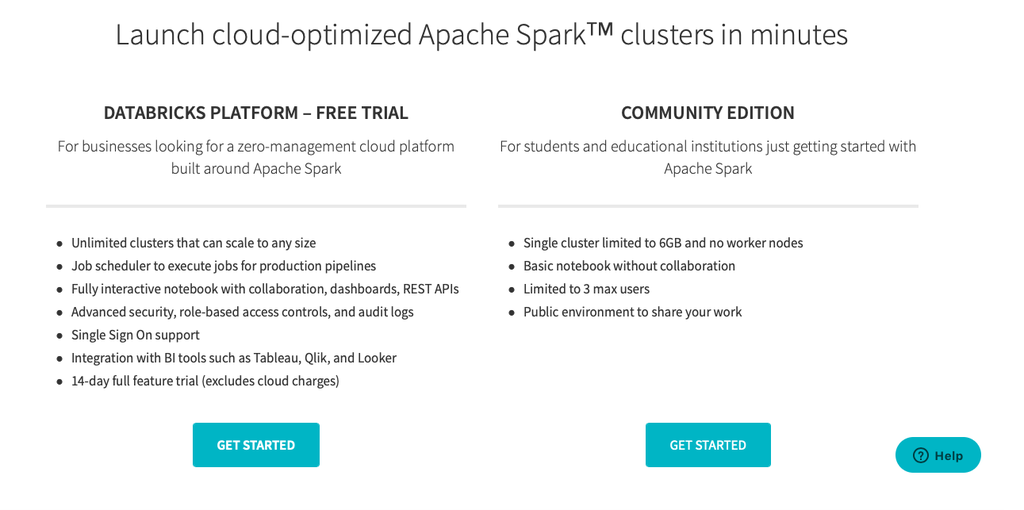

Fill in the form to sign up.

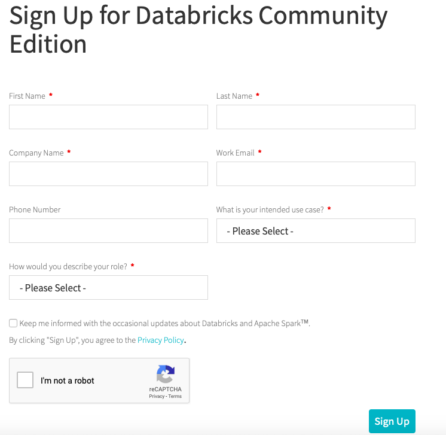

Check your email for a validation email, and enter a password. If you don’t receive a validation email, press `Forgot Password?` and fill in the details to get it resent.

# How to Log in

Login at this URL: https://community.cloud.databricks.com/login.html

[figure not shown]

**NOTE:** The `LOG IN` button in the top right of the databricks home page will bring you to the page below for `Account Owner Login`. Do not log in here, as it will ask for credit-card details, but press the `Looking for Community Edition? Sign in here.` link below.

[figure not shown]

This will take you to the below welcome page. This page has useful shortcuts, such as creating New Notebooks, Uploading Data, starting a New Cluster, and accessing recently opened workbooks. The tab on the left is always available, and also has shortcuts to `Workspace`, where you can see notebooks you have created, `Data`, where you can view data uploaded as tables and add more data, and `Clusters`, where you can create a new Cluster, or terminate an existing one.

[figure not shown]

# How to create a Cluster

Click on `Clusters` and `Create Cluster` at the top to create a Cluster for your Notebook. Ensure that the Python Version is set to 3 and fill in a name for the Cluster. Press `Create Cluster` to create the cluster.

[figure not shown]

Once you have clicked `Create Cluster`, you will see a page of `Interactive Clusters`, which should include at the top the one you have just created, and its state - `Pending`, if it is still in the process of being created, or `Running`, if it is active. Clusters will terminate after 2 hours of inactivity, and any local variables will be lost. Terminated clusters will have the state of `Terminated`, and within the community edition cannot be restarted. Instead, a new cluster will have to be created.

**Note** While local variables will be lost within a Notebook on cluster termination, raw data that has been uploaded to the system will still be accessible, and code written within a Notebook will remain.

# How to create a Notebook

Press `databricks` in the top left to return to the start page, and click on `New Notebook` to create a notebook. If a Cluster is running, it should automatically connect to it. If you have no cluster created, you will need to manually attach one, which will be shown below.

**Create Notebook with no Cluster:**

[figure not shown]

**Create Notebook with existing Cluster:**

[figure not shown]

Your notebook can be found under the workspace tab in the future. Clicking the drop down arrow next to your username gives you a host of options to Create, Clone, Import and Export files and directories. Recently opened files will appear on the databricks home page - accessible by pressing `databricks` in the top left

[figure not shown]

# Introduction to Notebooks

A new Notebook will open with one cell - one block to enter code. New cells can be added above, or below existing cells, by mousing to the center of the cell at the top, or bottom respectively, and pressing the plus sign.

[figure not shown]

Underneath the Notebook name is the word `Attached` or `Detached`. If `Attached`, you don’t need to do anything - it has already connected to the cluster you have set up. If `Detached`, select this and choose the cluster you created. If you have no active clusters, create one as above, by going to the Clusters tab on the left hand side, return to the Notebook, and attach it.

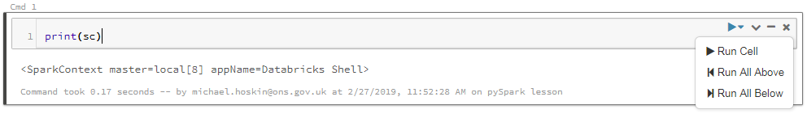

`print(sc)` should display the above result, stating that a `SparkContext` exists. This is one of the fundamental objects used to perform distributed actions within databricks.

The keyboard icon on the top menu bar on the right hand side can be used to find keyboard shortcuts for various cell operation tasks - moving them, inserting them, running all, copying and pasting cells etc.

From within this Notebook, you can write normal Python commands and execute them, read data that has been uploaded to databricks, and perform distributed tasks using Pyspark.

# Import Data to Databricks as a CSV

To complete the exercises within Databricks, we first need to upload the Data. You should have received a number of CSV files, each of which should be uploaded. Click on `Data` on the bar on the left and then `Add Data`.

[figure not shown]

Click on `browse` to find and upload the file you want. This will upload it as a CSV file, at the location specified e.g. `FileStore/tables/Item_Price.csv`.

[figure not shown]

# Import Data as an SQL table

Immediately after uploading your data as a CSV, we can convert it into a distributed SQL table. After importing the data as a CSV, click on `Create Table with UI` and select the Cluster you started earlier.

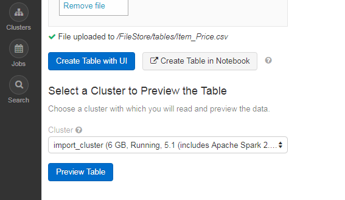

Click on `Preview Table` and take a look at the table. Column names will default to `_c0`, `_c1` etc for the zeroth, first indexed columns, and the column names (if present in the CSV file) will be placed into the first record. Column types will default to `String`.

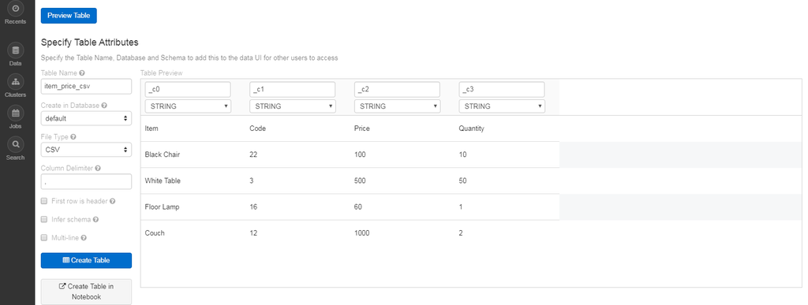

**IMPORTANT:**

- If your CSV file has a header, tick `First row is header`.
- Either manually change each columns datatype, or tick `Infer schema` to have databricks do it for you.
- Change the name as desired - two tables cannot have the same name. The name of the table will default to `filename_ext` - so `data.csv` will be saved as a table `data_csv`.

After any settings are changed, the visual table of example data should update to reflect the changes made.

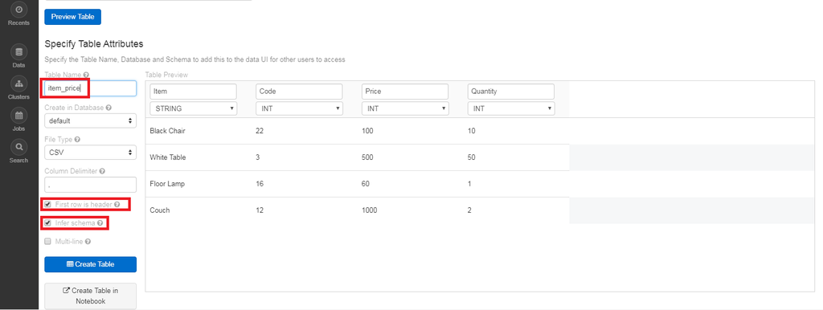

Once happy with your settings, select `Create Table`. The Data tab on the left will now show your created table within the `default` database - this is useful for finding exact names of tables for exercises.

This data is then ready to be read into a databricks Notebook, using commands that will be explained in the course material.

## Import from FileStore to an SQL table

If you have made a mistake when converting a CSV file into an SQL table, you can point the Data Source to the previously uploaded CSV and recreate the table, but you will need to name it something different as you cannot overwrite previous tables.

From `Data` > `Add Data`, instead of `Upload File`, go to `DBFS` (databricks File Store), and then navigate to `FileStore\tables\` where a list of uploaded files should be available to you. Select the one you want, and then follow the `Create Table with UI` instructions as above. As before, an active cluster is required.

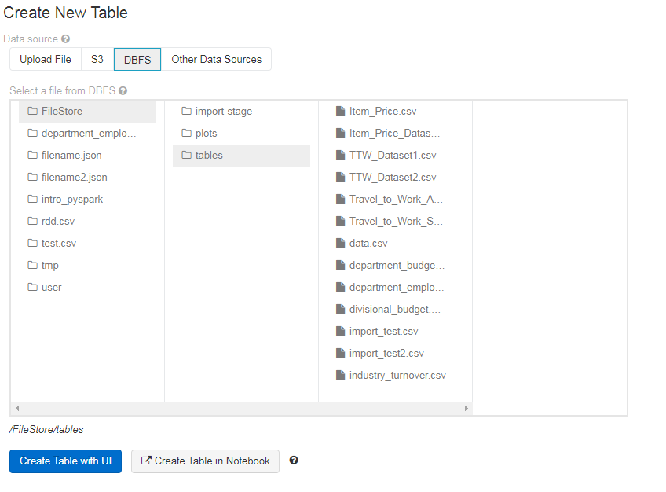

This is the most convenient way to view data which you have written to file from within databricks - from the image above, the top level directories `intro_pyspark`, `rdd.csv`, `filename.json` etc were created from databricks notebooks and can be observed here.